# Trp53cor1 KO vs WT (Liver)

This file shows the wt-v-ko comparison for Trp53cor1.

Cuff overview:

```
## CuffSet instance with:
##   2 samples
##   26754 genes
##   77524 isoforms
##   0 TSS
##   23066 CDS
##   0 promoters
##   0 splicing
##   19954 relCDS
```

# QC

## Dispersion

Dispersion plot for genes in cuff: (Overdispersion can lead to innacurate quants)

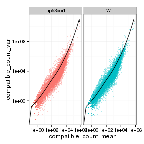

## Cross-replicate variability (fpkmSCVplot)

Differences in CV 2 can result in lower numbers of differentially expressed genes due to a higher degree of variability between replicate fpkm estimates.

Genes:

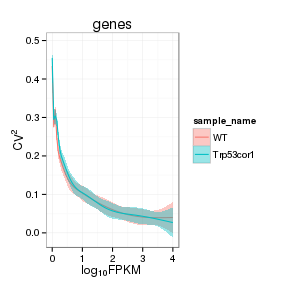

Isoforms:

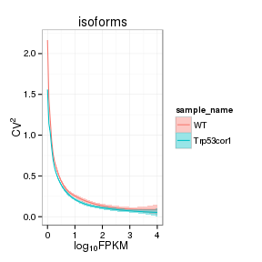

## MvA plot

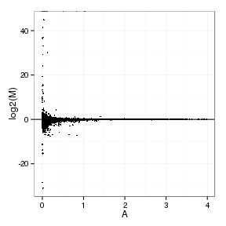

### MvA plot counts

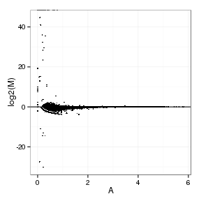

## Scatterplot matrix

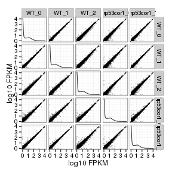

## Distributions

### Boxplots

Boxplot (genes)

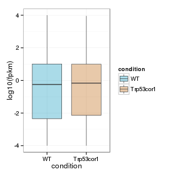

Boxplot (genes, replicates)

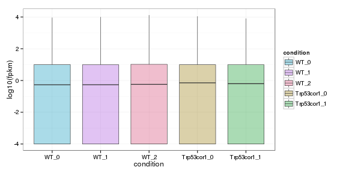

Boxplot (isoforms)

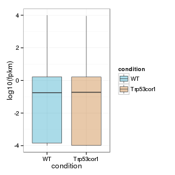

Boxplot (isoforms, replicates)

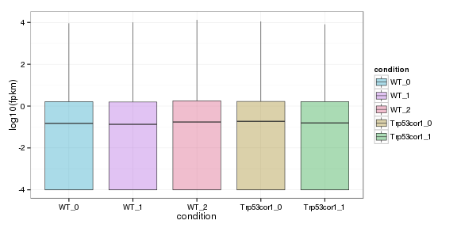

### Density

Density (genes)

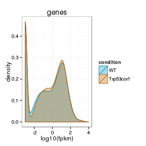

Density (genes, replicates)

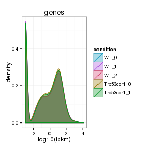

## Clustering

### Replicate Clusters

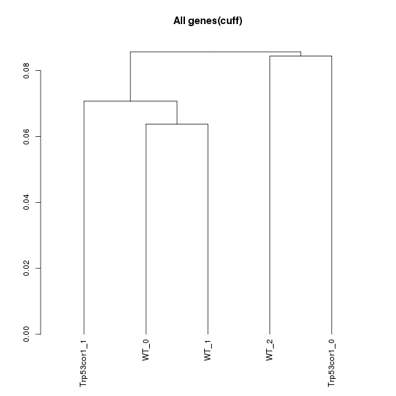

### PCA (genes)

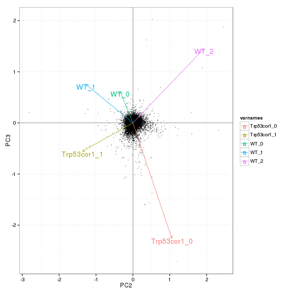

### MDS (genes)

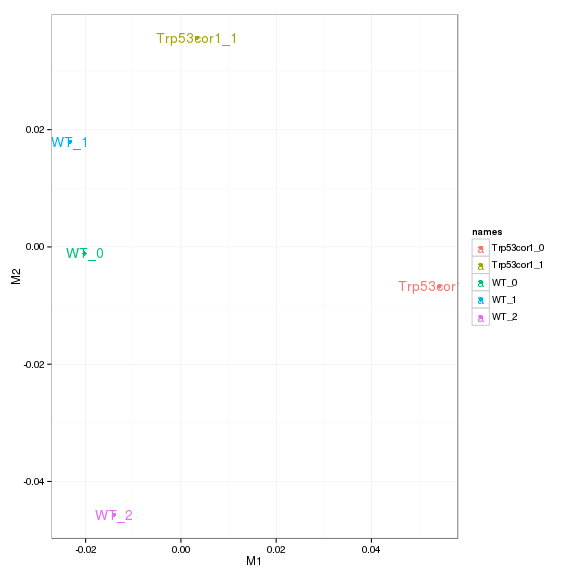

# KO assessment

## Endogenous lncRNA expression

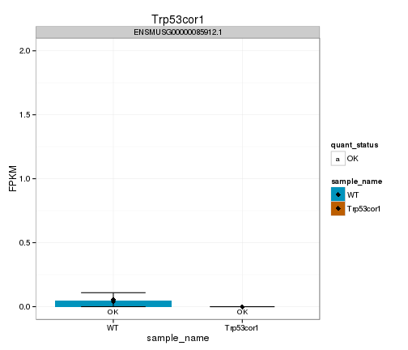

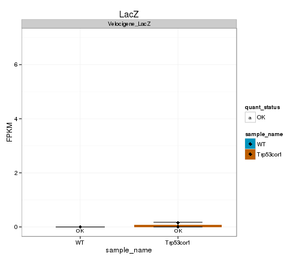

## Digital Genotyping (LacZ vs Endogenous lncRNA and Sex)

Eif2s3y is a y-expressed gene, Xist is an x-expressed gene Expression plot (endogenous linc, lacZ, Y-expressed gene):

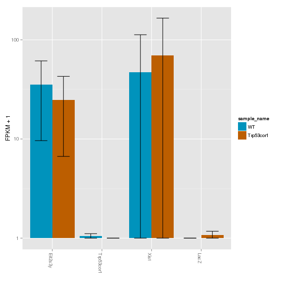

Expression heatmap:

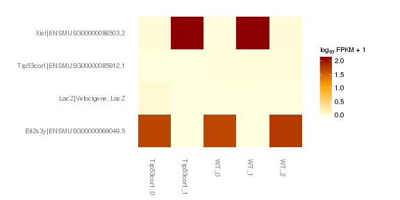

### Track visualization

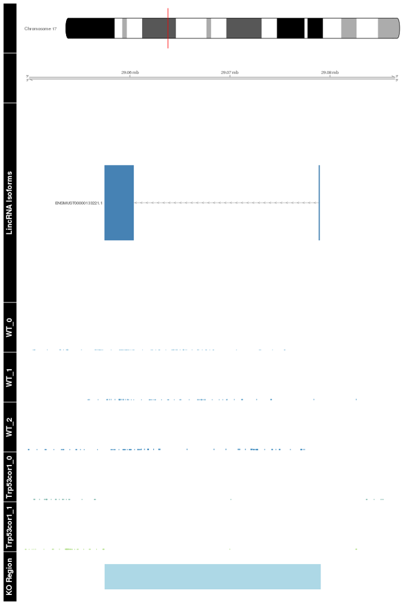

# Differential Analysis

## Differential Genes

There are 141 significantly differentially expressed genes. They are:

|  | geneAnnot$gene_short_name |
| --- | --- |
| 1 | Gcg |
| 2 | Sox9 |
| 3 | Col6a1 |
| 4 | Cnn1 |
| 5 | Col1a1 |
| 6 | Sst |
| 7 | Wisp1 |
| 8 | Ephb3 |
| 9 | Cav1 |
| 10 | Celsr1 |
| 11 | Sulf1 |
| 12 | Gast |
| 13 | Pyy |
| 14 | Wfdc2 |
| 15 | Jph2 |
| 16 | Myh11 |
| 17 | Col6a2 |
| 18 | Myl7 |
| 19 | Ntn1 |
| 20 | Krt19 |
| 21 | Galnt16 |
| 22 | Barx1 |
| 23 | Cartpt |
| 24 | Adamdec1 |
| 25 | Efs |
| 26 | Sema5a |
| 27 | Trp63 |
| 28 | Slc15a2 |
| 29 | Cdkn1a |
| 30 | Nfatc4 |

[output cut: 111 more lines]

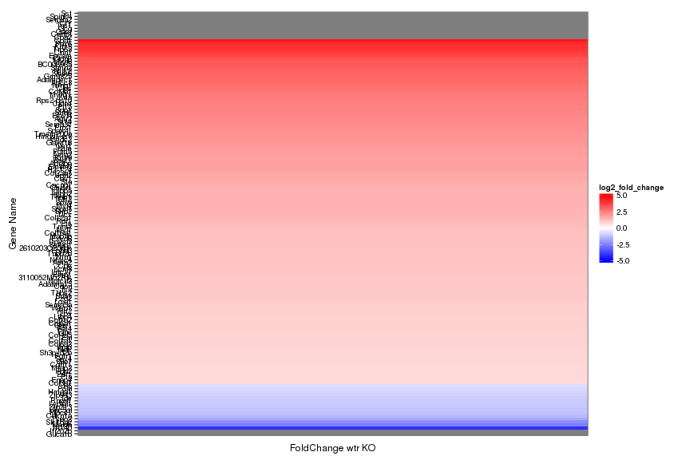

Expression heatmap of sigGenes

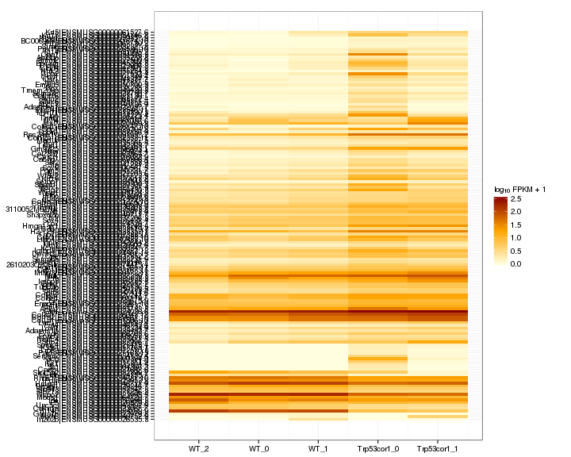

Foldchange heatmap of sigGenes

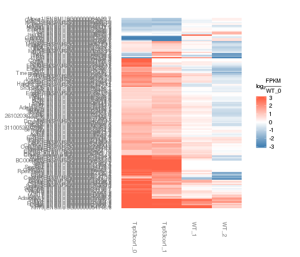

Now, look at genes that are detectably expressed (FPKM>0.5, yes I know it should be 1), and log2foldchange>2 in any direction: 116 genes

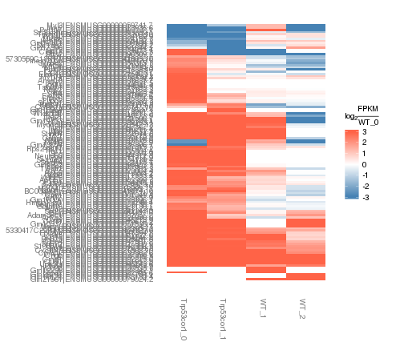

Now, those that are expressed, changing and called sig: 39 genes

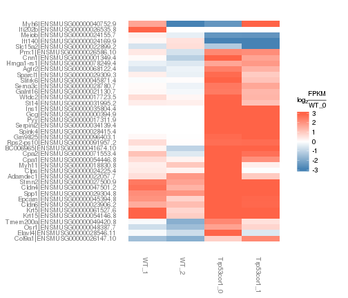

### Expression-level/significance relationship

Scatter plot of significant genes only:

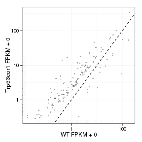

Volcano Plot

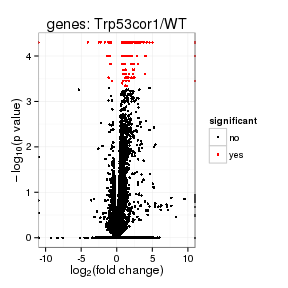

Volcano plot with significant genes only:

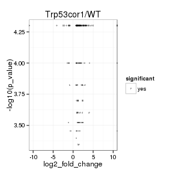

### Differential Isoforms between conditions

Per isoform difference between conditions:

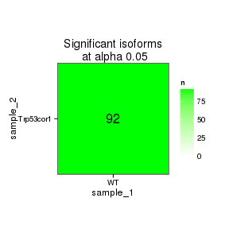

[output not shown]

[output not shown]

[output not shown]

[output not shown]